# Sandy

Marcela

8/26/2019

## **Analysis with the whole dataset**

#### **A general overview of the dataset**

```
## Classes 'spec_tbl_df', 'tbl_df', 'tbl' and 'data.frame': 141909 obs. of  7 variables:
##  $ lat      : num  30 34.1 40.4 43.2 40.6 ...
##  $ lon      : num  -94.1 -118.4 -80.7 -77.7 -111.9 ...
##  $ date     : POSIXct, format: "2012-10-24 00:00:14" "2012-10-24 09:19:11" ...
##  $ state    : chr  "Texas" "California" "Ohio" "New York" ...
##  $ text     : chr  "I swear #OVH6 nd #RTM is flooding my TL!!" "Car flood victim says, \"My car just sputtered dead.\"" "\"I wasn't that drunk!\" \"Dude, you threw a squirrel into the water screaming 'Bikini Bottom needs you Sandy!'"| __truncated__ "Back to cstate with a special delivery for @FLO…
##  $ user_id  : num  2.40e+08 1.75e+08 3.82e+08 2.87e+08 1.52e+08 ...
##  $ u_profile: chr  "Taking on life and it's challenges...Living life with no regets... BTW follow my BackBone @Chung_Lei ... #LamarUniversity" "General Assignment Reporter for NBC LA." "Senior @ EHS #wrestler#getswoll#110%" "We should be looking at our potential, stretching ourselves into everyth…
```

Tweets were collected from 2012-10-24 00:00:14 to 2012-10-31 23:59:41

#### **Cleaning dataset**

- *Removing retweets:*

  From the original dataset containing 141909 tweets, only 137708 were retained.
- *Removing tweets sent by bots:*
- *Removing urls, usernames, punctuation and numbers:*

  All references to usernames, urls and punctuation and numbers were removed from each tweet in order to prepare the dataset for tokenization.

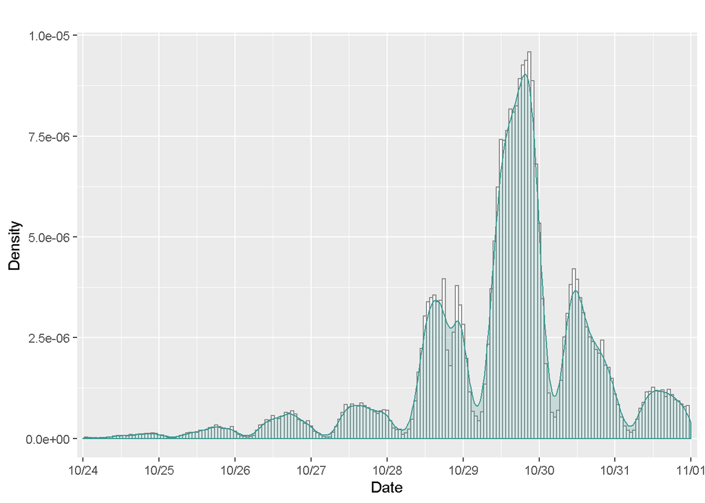

Note: There were 63515 observations on October 29

#### **Temporal stages**

Four stages were defined:

- *preCalm*: From 2012-10-24 00:00:14 to 2012-10-28 06:00:00.
- *prePeak*: From 2012-10-28 06:00:00 to 2012-10-29 06:00:00.
- *peak*: From 2012-10-29 06:00:00 to 2012-10-30 06:00:00.
- *postCalm*: From 2012-10-30 06:00:00 to 2012-10-31 23:59:41.

#### **Most common words**

A quick view of the most common words in the whole dataset:

```
## # A tibble: 80,567 x 2
##    word              n
##    <chr>         <int>
##  1 sandy        123160
##  2 hurricane     33103
##  3 frankenstorm  10175
##  4 im             9726
##  5 power          6100
##  6 storm          5512
##  7 nyc            5429
##  8 amp            5122
##  9 safe           4300
## 10 flooded        3914
## # ... with 80,557 more rows
```

```
## # A tibble: 80,562 x 2
##    word         n
##    <chr>    <int>
##  1 power     6100
##  2 storm     5512
##  3 nyc       5429
##  4 safe      4300
##  5 flooded   3914
##  6 east      3838
##  7 dont      3666
##  8 flood     3554
##  9 york      3507
## 10 flooding  3499
## # ... with 80,552 more rows
```

The statistic **tf-idf** was computed in order to identify which words are important in each of the flood stages. It measures how important a word is to a document in a collection (or corpus) of documents, in our case, it measures how important a word is to a tweet in a collection of tweets. In this case the collection of tweets was the set of tweets belonging to each stage.

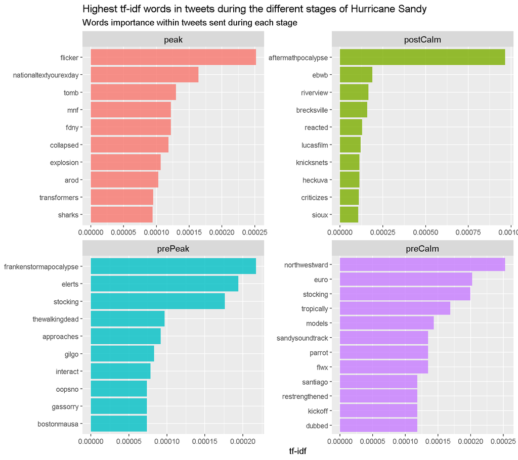

#### **Topic Modeling**

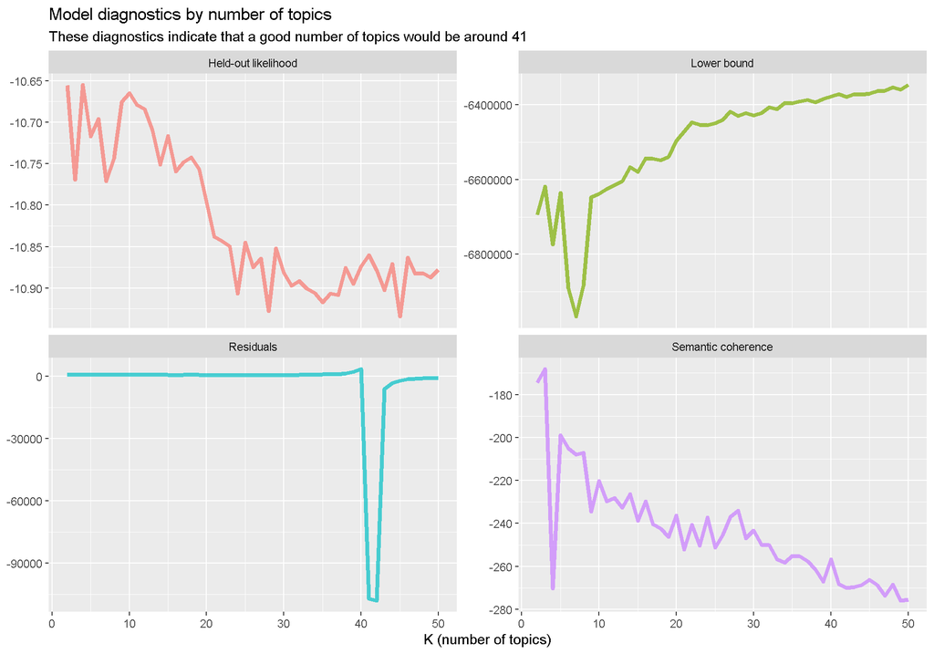

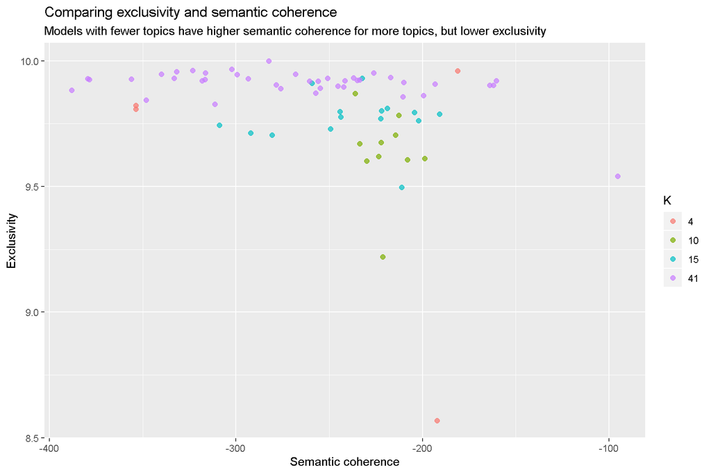

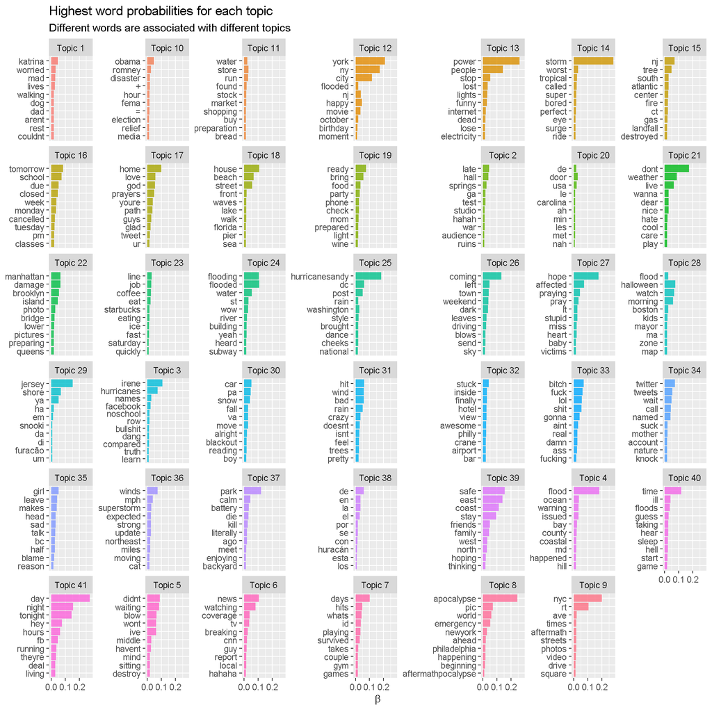

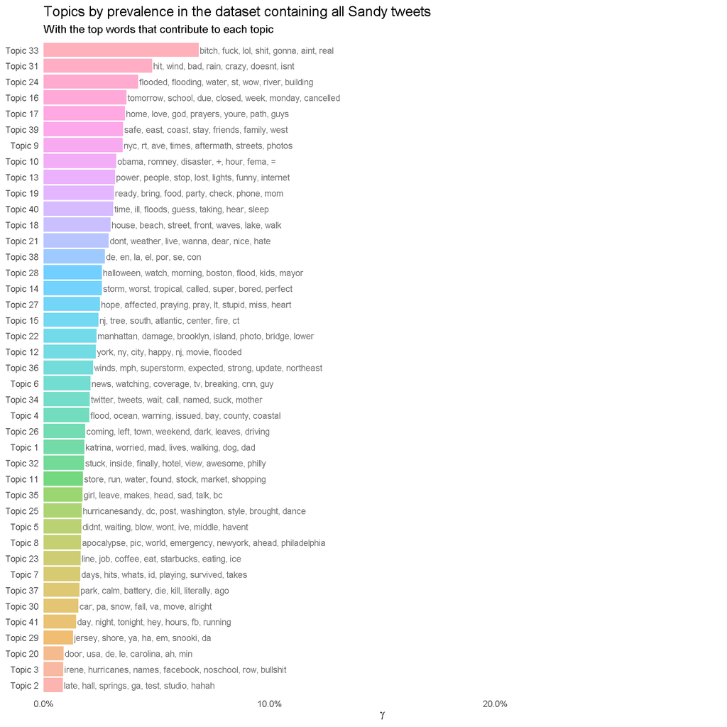

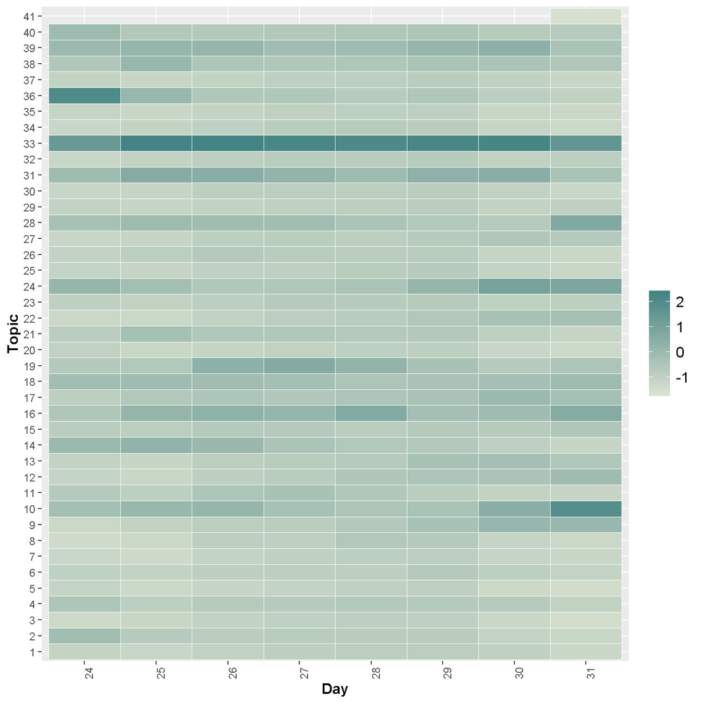